# Problem Set 3: Droughts & Transportation

Replicating graphs displaying droughts in the USA & transportation distances in Spain

Author

Michael Fehl, Francesco Zucca, Joan Costa, Xenia Alemany

Published

February 25, 2026

```r
# load in libraries
rm(list=ls())
library(terra)         # raster operations
library(exactextractr) # exact_extract() for distances
library(gdistance)     # fast distance() formula for geo data
library(sf)            # vector operations
library(spData)        # geo data
library(tidyverse)     # NOTE: Conflict -- tidyr::extract() masks terra::extract()
library(glue)          # printf() syntax
library(spDataLarge)   # geo data
library(ggrepel)       # add labels to ggplot
library(tidyterra)     # visualize geospatial using tidy syntax
library(patchwork)     # patch tg ggplot objects
```

# Assignment

**Goal** : Model the following:

1. Climate Change in the USA
2. Transportation Isolation & Centrality in Spain

# Part 1: Climate Change

## Task

Calculating climate change in USA

## Reference

Attached is the figure we are attempting to replicate qualitatively (not identically):

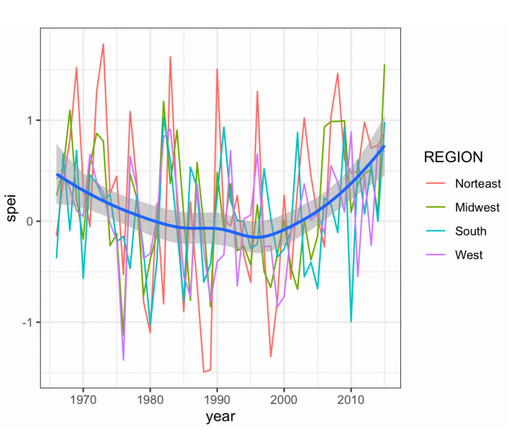

Drought Risk by Year & Region

Figure 1: SPEI Drought Index: USA

## Data Source 1: SPEI Drought Index

[Data Source](https://spei.csic.es/database.html)

```r
drought <- rast("data/spei01.nc")
drought # inspect
```

```
class       : SpatRaster
size        : 180, 360, 910  (nrow, ncol, nlyr)
resolution  : 1, 1  (x, y)
extent      : -180, 180, -90, 90  (xmin, xmax, ymin, ymax)
coord. ref. : lon/lat WGS 84 (CRS84) (OGC:CRS84)
source      : spei01.nc
varname     : spei (standardized precipitation-evapotranspiration index)
names       :              spei_1,              spei_2,              spei_3,              spei_4,              spei_5,              spei_6,                 ...
unit        : standardized values
time (days) : 1950-01-01 to 2025-10-01 (910 steps)
```

# Part 2: Transportation

## Task

Visualizing transportation centrality and isolation across Spain

- Use the ne_10m_populated_places shapefile to retrieve the top-10 populated places
- Crop the ne_10m_roads data within Spain
- Build a raster/friction surface; calculate distances between all city pairs
- Bilateral distances if coming from Madrid vs. Vigo: who is more isolated?
  - geom_density(): calculates “smoothed” distributions

## Reference

Attached are the figures we are attempting to replicate qualitatively (not identically):

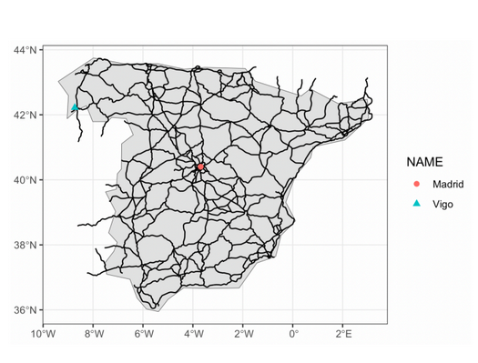

Transportation Infrastructure in Spain

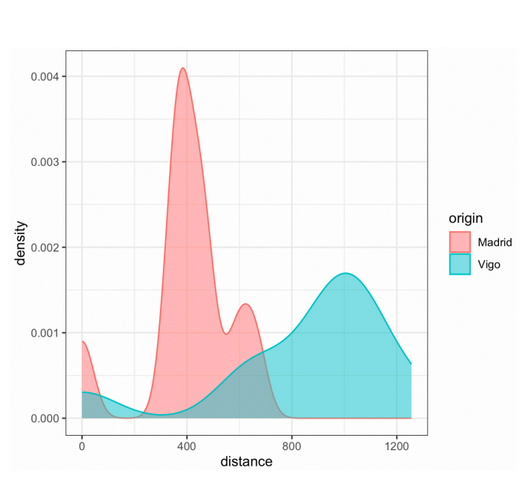

Density of Distances to Transportation

Figure 2: Transportation and Isolation in Spain: Madrid vs Vigo

## Data Source 1: Natural Earth

[Data Source](https://www.naturalearthdata.com/downloads/10m-cultural-vectors/)

```r
sf.roads <- st_read("data/ne_10m_roads/ne_10m_roads.shp")
sf.cities <- st_read("data/ne_10m_populated_places/ne_10m_populated_places.shp")
sf.spain <- spData::world %>%
  filter(name_long == "Spain")
```

**TipProjection**

All three of sf.roads, sf.cities, and sf.spain share the same projection style WGS84, so there is no need to recast any of them.

### 2.1: Roads Map

#### Filter Populated Cities

First, we want to filter for the top 10 most populated cities in Spain

```r
sf.cities_spain10 <- sf.cities %>%
  filter(ADM0NAME == "Spain") %>%
  select(NAME, POP_MAX, geometry) %>%
  arrange(desc(POP_MAX)) %>%
  slice(1:10)
```

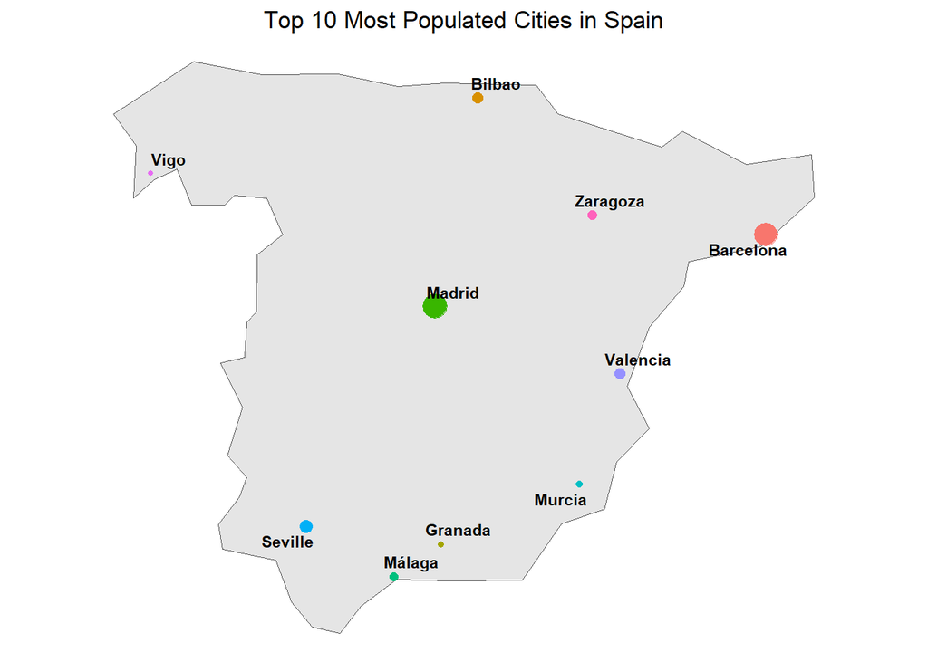

```r
# sanity check
ggplot() +
  geom_sf(data=sf.spain) +
  geom_sf(data=sf.cities_spain10,
          aes(size = POP_MAX,
              color = NAME)) +
  geom_text_repel(data = sf.cities_spain10,
                  aes(label = NAME, geometry = geometry),
                  stat = "sf_coordinates",
                  size = 3, fontface = 'bold') +
  labs(title = "Top 10 Most Populated Cities in Spain") +
  theme_void() +
  theme(legend.position = 'none',
        plot.title = element_text(hjust=0.5))
```

```r
# table of populations
sf.cities_spain10 %>%
  st_drop_geometry() %>%
  rename(City = NAME,
         Population = POP_MAX)
```

```
        City Population
1     Madrid    5567000
2  Barcelona    4920000
3    Seville    1212045
4     Bilbao     875552
5   Valencia     808000
6   Zaragoza     649404
7     Málaga     550058
8     Murcia     406807
9    Granada     388290
10      Vigo     378952
```

**Note**

Note that our final map only cares about Madrid and Vigo, but we need the top 10 most populated cities to calculate distances between cities. We will drop them once we move onto the final map recreation.

#### Crop Spain Roads

Next, we will crop the world road data to just be contained within Spain, using the vector operations `sf::st_intersection()`

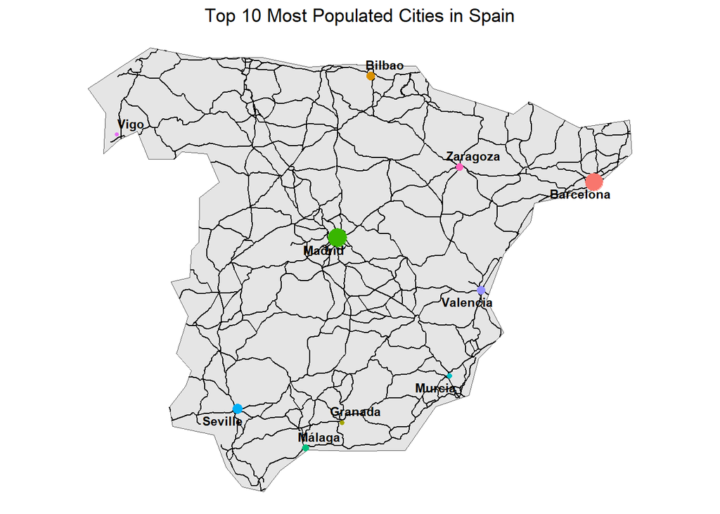

```r
# filter for roads in spain
sf.roads_spain <- st_intersection(sf.roads, sf.spain)

# sanity check
ggplot() +
  geom_sf(data=sf.spain) +
  geom_sf(data=sf.roads_spain) +
  geom_sf(data=sf.cities_spain10,
          aes(size = POP_MAX,
              color = NAME)) +
  geom_text_repel(data = sf.cities_spain10,
                  aes(label = NAME, geometry = geometry),
                  stat = "sf_coordinates",
                  size = 3, fontface = 'bold') +
  labs(title = "Top 10 Most Populated Cities in Spain") +
  theme_void() +
  theme(legend.position = 'none',
        plot.title = element_text(hjust=0.5))
```

#### Raster Template

To calculate distances between all city pairs, we must create a raster surface, cropped to fit the bounds of our `sf.spain` vector object.

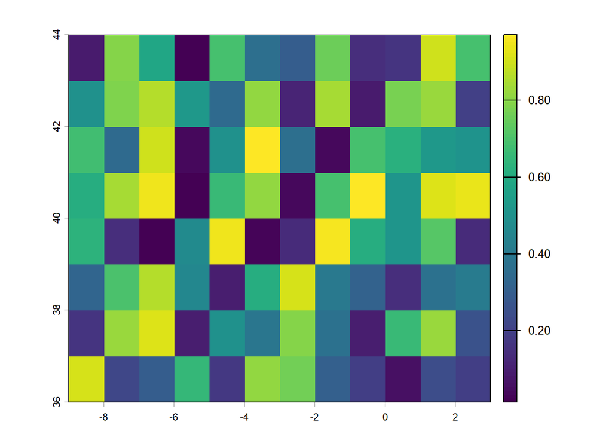

```r
r.template <- rast()
values(r.template) <- runif(1:ncell(r.template))

# crop to spain bounds
r.template <- terra::crop(r.template, sf.spain)

# sanity check
plot(r.template)
```

To make our calculations more precise, we want to redefine this resolution. Note that we also will adjust the cropping to give the map a bit of ‘breathing room’, as sometimes `terra::crop()` can cut off edges of the map.

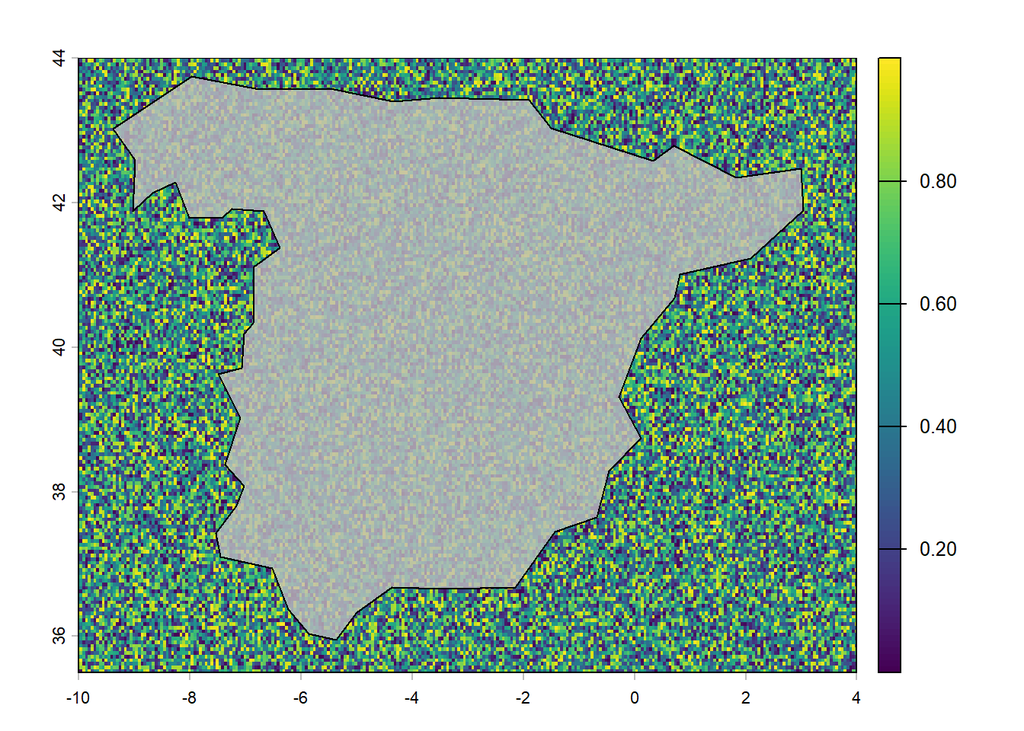

```r
ext(r.template) <- c(-10, 4, 35.5, 44) # manually cropping
res(r.template) <- 0.05                # set res to much finer for more precision
values(r.template) <- runif(1:ncell(r.template))

# sanity check
plot(r.template)
plot(st_geometry(sf.spain), add=T, col=adjustcolor("gray", alpha.f=0.8))
```

#### Rasterize

Now we can find the sf.cities_spain10 multipoints that intersect with our r.spain raster gridcells to calculate distances from one another. To do so, we first must rasterize our sf.spain vector object, using the newly created raster template.

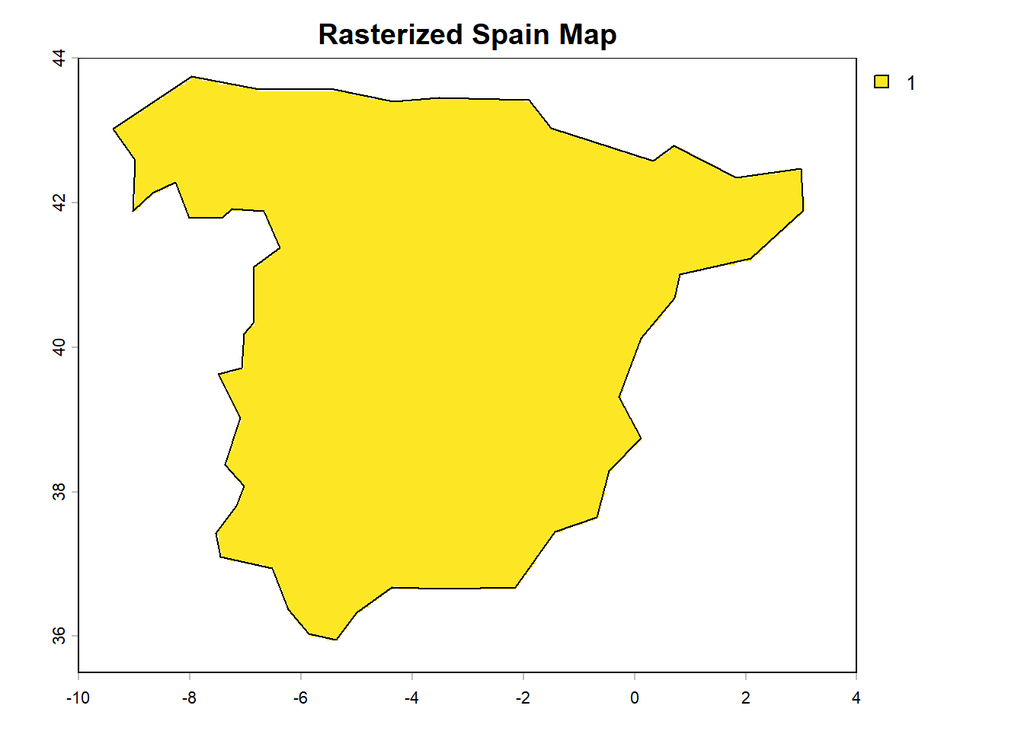

```r
r.spain <- terra::rasterize(x=sf.spain,    # vector object
                            y=r.template,  # template raster
                            field = 1)     # optional: set touching vals = 1

# cells on the network = 1, off-network = NA
plot(r.spain, main = "Rasterized Spain Map")
plot(st_geometry(sf.spain), add = TRUE)
```

The map seems to almost perfectly rasterize the sf.spain polygon, contained within the borders outlined by the vector object. Next, we must convert this rasterized object into a transition matrix such that we can perform matrix operation on it. We do so using the `gdistance::transition()` function.

#### Transition Matrix

**Warning**

Since the `transition()` function comes from the `gdistance` library, we need to make sure our raster object is a RasterLayer, not a SpatRaster object from the `terra` library. We convert this type before passing in our filled out r.spain raster object into the transition matrix function.

```r
# convert NA values to 0 to compute distances later on
r.spain_filled <- r.spain
r.spain_filled[is.na(r.spain_filled)] <- 0 # replace NA values with 0

# convert: SpatRaster -> RasterLayer
r.spain_filled <- raster::raster(r.spain_filled)

# transition matrix
trans <- gdistance::transition(
  x = r.spain_filled,             # must be a gdistance::RasterLayer object
  transitionFunction = mean,
  directions = 8                  # max 8-gridcells surrounding any given gridcell
)
```

**Note**

We must convert the NA values to become 0. That way, any distance operations do not fail (when we pass NA) and only matter for non-zero integers. We do this using the `is.na()` function called onto our newly rasterized r.spain object.

Note that after we build the matrix, we must correct for diagonal distances, as in a grid, the distance between two horizontally or vertically adjacent cells is 1 cell width. But the distance between two diagonally adjacent cells is $\sqrt{2} \approx 1.414$ cell widths. Without correction, the algorithm treats both as equal cost.

```r
# correct for diagonal distances (geometric correction)
trans_corrected <- geoCorrection(trans, type = "c")
```

#### Distances between Cities

To calculate distances between points, we use the `gdistance::shortestpath()` function, which employs a ‘minimum-cost’ ([Dijkstra](https://en.wikipedia.org/wiki/Dijkstra%27s_algorithm)) pathfinding algorithm.

Importantly, we must select a start and end point in our raster object for the algorithm to calculate the shortest path between. We will select these points as the 10 city geometries, and run them through a loop to retrieve every possible city-pair distance.

```r
cities <- sf.cities_spain10$NAME                      # extract city names
city_geoms <- st_geometry(sf.cities_spain10)          # extract city geoms
city_pairs <- matrix(data = NA, nrow = 10, ncol = 10,
                     dimnames = list(cities, cities)) # initialize empty matrix of dist
city_paths <- list()                                  # init empty list to store paths

# loop
for (i in 1:10) {
  for (j in 1:10) {
    if (i == j) {
      city_pairs[i, j] <- 0  # distance to itself
    } else {
      path <- gdistance::shortestPath(
        x     = trans_corrected,
        origin  = as(city_geoms[i], "Spatial"),
        goal    = as(city_geoms[j], "Spatial"),
        output  = "SpatialLines"
      )
      city_pairs[i, j] <- SpatialLinesLengths(path, longlat = TRUE)
      city_paths[[paste(cities[i], cities[j], sep = "_")]] <- path  # store path
    }
  }
}

# table results
city_pairs
```

```
            Madrid Barcelona  Seville   Bilbao Valencia Zaragoza    Málaga
Madrid      0.0000  542.3479 401.0980 331.1217 328.2888 303.1803 432.48183
Barcelona 542.3479    0.0000 906.3863 521.3434 340.3964 270.6742 817.70685
Seville   401.0980  906.3863   0.0000 728.6096 590.6465 667.4886 174.78427
Bilbao    331.1217  521.3434 728.6096   0.0000 485.2652 254.8729 762.41621
Valencia  328.2888  340.3964 590.6465 485.2652   0.0000 256.8684 496.59463
Zaragoza  303.1803  270.6742 667.4886 254.8729 256.8684   0.0000 652.89436
Málaga    432.4818  817.7068 174.7843 762.4162 496.5946 652.8944   0.00000
Murcia    353.1153  527.5467 455.7765 632.0327 187.3093 417.7812 357.63403
Granada   363.6666  720.2091 225.8171 689.2045 398.1418 577.3388  99.55802
Vigo      529.4217  957.4992 716.1003 527.9821 852.1116 689.1437 838.26184
            Murcia   Granada     Vigo
Madrid    353.1153 363.66656 529.4217
Barcelona 527.5467 720.20915 957.4992
Seville   455.7765 225.81708 716.1003
Bilbao    632.0327 689.20448 527.9821
Valencia  187.3093 398.14184 852.1116
Zaragoza  417.7812 577.33878 689.1437
Málaga    357.6340  99.55802 838.2618
Murcia      0.0000 258.45402 882.2935
Granada   258.4540   0.00000 813.4894
Vigo      882.2935 813.48943   0.0000
```

Here, we can visualize the shortest distances between Madrid and the other 9 largest cities in Spain, and vice-versa for Vigo.

**Important**

One might expect for the shortest distance between two cities to be a straight line; however, note that the `shortestpath()` function is calculated based on our non-zero gridcells. If we increase the precision by decreasing the resolution further, we would likely see straighter and straighter lines connecting the cities. This however, comes at a cost of more computational power. Since our goal is not about paths between cities, we will not concern ourselves with such a level of precision.

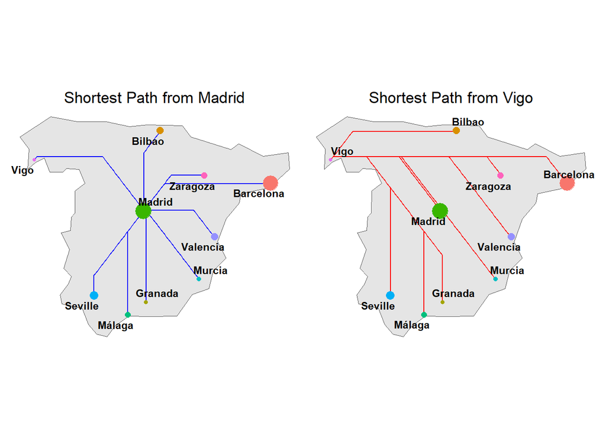

```r
madrid_paths_sf <- lapply(city_paths[grep("^Madrid_",
                                          names(city_paths))],
                          st_as_sf) %>%
  bind_rows() %>%
  st_set_crs(st_crs(sf.cities_spain10))

# madrid plot
p1<-ggplot() +
  geom_sf(data=sf.spain) +
  geom_sf(data = madrid_paths_sf, color = "blue") +
  geom_sf(data=sf.cities_spain10,
          aes(size = POP_MAX,
              color = NAME)) +
  geom_text_repel(data = sf.cities_spain10,
                  aes(label = NAME, geometry = geometry),
                  stat = "sf_coordinates",
                  size = 3, fontface = 'bold') +
  labs(title = "Shortest Path from Madrid") +
  theme_void() +
  theme(legend.position = 'none',
        plot.title = element_text(hjust=0.5))

vigo_paths_sf <- lapply(city_paths[grep("^Vigo_",
                                          names(city_paths))],
                          st_as_sf) %>%
  bind_rows() %>%
  st_set_crs(st_crs(sf.cities_spain10))

# vigo plot
p2<-ggplot() +
  geom_sf(data=sf.spain) +
  geom_sf(data = vigo_paths_sf, color = "red") +
  geom_sf(data=sf.cities_spain10,
          aes(size = POP_MAX,
              color = NAME)) +
  geom_text_repel(data = sf.cities_spain10,
                  aes(label = NAME, geometry = geometry),
                  stat = "sf_coordinates",
                  size = 3, fontface = 'bold') +
  labs(title = "Shortest Path from Vigo") +
  theme_void() +
  theme(legend.position = 'none',
        plot.title = element_text(hjust=0.5))

p1+p2
```

#### Final Graph

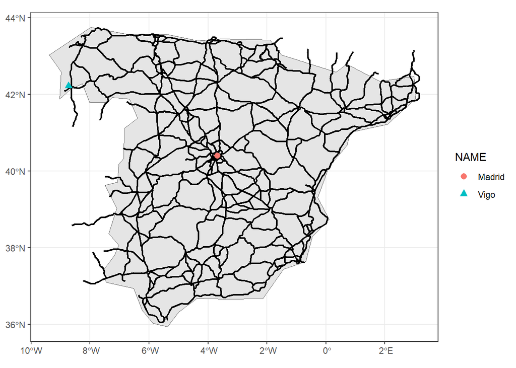

```r
sf_cities_spain2 <- sf.cities_spain10 %>%
  filter(NAME == "Madrid" | NAME == "Vigo")

sf.roads_spain2 <- sf.roads %>%
  filter(featurecla == "Road") %>%                     # filter out boat travel (ferries)
  st_filter(sf.spain, .predicate = st_intersects) %>%  # keep only roads that touch Spain
  st_simplify(dTolerance = 500)                        # simplify the roads slightly to match

ggplot() +
  geom_sf(data=sf.spain) +
  geom_sf(data=sf.roads_spain2, lwd=0.75) +
  geom_sf(data=sf_cities_spain2,
          aes(color = NAME, shape = NAME), size = 2.5) +
  scale_shape_manual(values = c("Madrid" = 16, "Vigo" = 17)) +
  theme_bw() +
  theme(plot.title = element_text(hjust=0.5))
```

Our resulting plot looks to be nearly 1-1 mapping qualitatively to the reference photo:

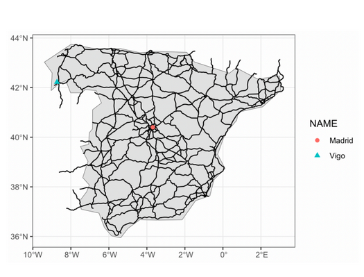

Transportation Infrastructure in Spain

### 2.2: Densities Graph

Thanks to our city-pair distance matrix we created earlier, we can easily create our final graph based on the distances between cities:

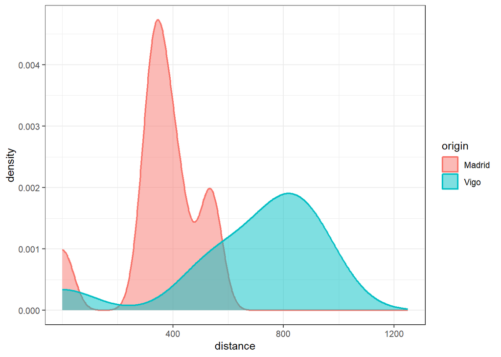

```r
df <- data.frame(
  distance = c(as.numeric(city_pairs['Madrid', ]), as.numeric(city_pairs['Vigo', ])),
  city = rep(c("Madrid", "Vigo"), each = ncol(city_pairs) )
)

ggplot(df, aes(x = distance,
               fill = city,
               color=city)) +
  geom_density(alpha = 0.5, lwd=0.75) +
  labs(fill = "origin",
       color = "origin") +
  scale_x_continuous(breaks = c(400, 800, 1200), limits = c(0, 1250)) +
  theme_bw()
```

Compared to our reference photo:

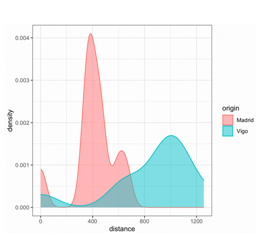

Density of Distances to Transportation

Back to top